# Pertemuan 2 - Regresi Soal 2

Naurah Aathirah Farid

# Pemanggilan *Packages*

```r
library(dplyr)
library(TTR)
library(forecast)
library(lmtest) #digunakan untuk uji formal pendeteksian autokorelasi
library(orcutt) #untuk membuat model regresi Cochrane-Orcutt
library(HoRM) #untuk membuat model regresi Hildreth-Lu
```

# Input Data

Data yang digunakan dalam kesempatan kali ini adalah data penjualan (sales) sebagai peubah respon (Y) dan biaya iklan (advertising) sebagai peubah penjelas (X) sebagai peubah penjelas sebanyak 40 periode pengamatan tahun 1975-2014.

```r
year <- 1975:2014
sales <- c (11.7, 12.0, 12.3, 12.8, 13.1, 13.6, 13.9, 14.4, 14.7, 15.3,
            15.5, 15.8, 16.1, 16.6, 16.9, 16.7, 16.9, 17.4, 17.6, 17.9,
            18.0, 17.9, 18.0, 18.2, 18.2, 18.3, 18.6, 19.2, 19.3, 19.5,
            19.2, 19.3, 19.5, 20.0, 20.0, 19.9, 19.8, 19.9, 20.2, 21.0)
advertising <- c(9.4, 9.6, 10.0, 10.4, 10.8, 10.9, 11.7, 12.2, 12.5, 12.9,
                  13.0, 13.2, 13.8, 14.2, 14.6, 14.4, 15.0, 15.4, 15.7, 15.9,
                  15.9, 16.0, 16.3, 16.2, 16.8, 17.3, 17.6, 18.1, 18.3, 18.5,
                  18.7, 18.9, 19.2, 20.0, 20.0, 20.3, 20.4, 21.0, 21.5, 22.1)

dtsales <- cbind(year, sales, advertising)
dtsales <- as.data.frame(dtsales)
dtsales
```

```
##    year sales advertising
## 1  1975  11.7         9.4
## 2  1976  12.0         9.6
## 3  1977  12.3        10.0
## 4  1978  12.8        10.4
## 5  1979  13.1        10.8
## 6  1980  13.6        10.9
## 7  1981  13.9        11.7
## 8  1982  14.4        12.2
## 9  1983  14.7        12.5
## 10 1984  15.3        12.9
## 11 1985  15.5        13.0
## 12 1986  15.8        13.2
## 13 1987  16.1        13.8
## 14 1988  16.6        14.2
```

[output cut: 26 more lines]

# Eksplorasi Data

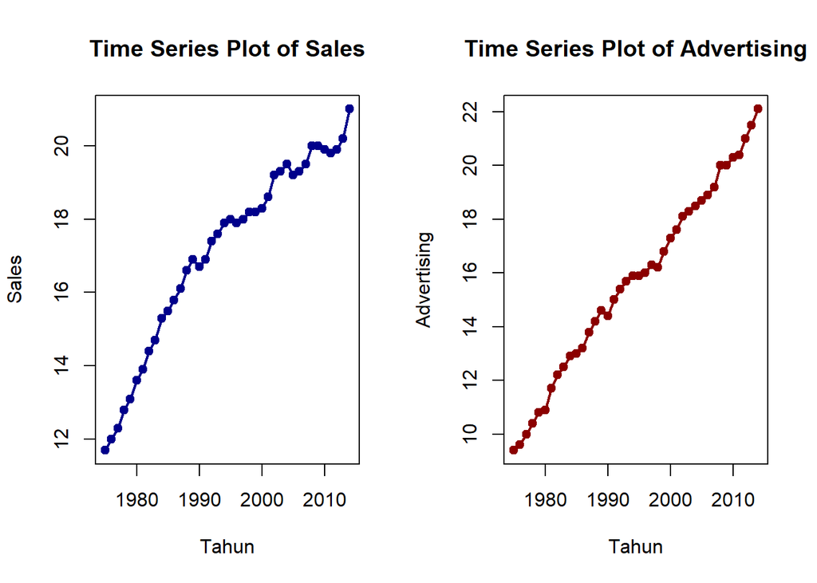

```r
# Membentuk objek time series
sales.ts <- ts(dtsales$sales, start = 1975)
adv.ts <- ts(dtsales$advertising, start = 1975)

# Plot time series masing-masing peubah
par(mfrow = c(1, 2))
ts.plot(sales.ts, xlab = "Tahun", ylab = "Sales",
        main = "Time Series Plot of Sales", col = "darkblue", lwd = 2)
points(sales.ts, pch = 19, col = "darkblue")

ts.plot(adv.ts, xlab = "Tahun", ylab = "Advertising",
        main = "Time Series Plot of Advertising", col = "darkred", lwd = 2)
points(adv.ts, pch = 19, col = "darkred")
```

Berdasarkan plot time series di atas, terlihat peubah sales maupun advertising sama-sama menunjukkan pola tren yang cenderung meningkat seiring bertambahnya waktu (upward trend).

# Hubungan Antar Peubah (Scatter Plot & Korelasi)

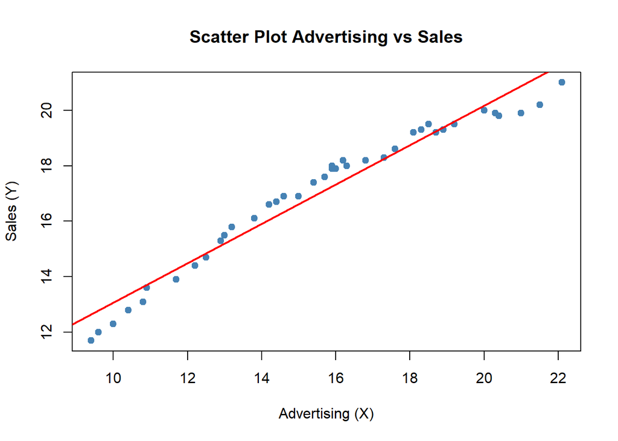

```r
par(mfrow = c(1, 1))
# Scatter Plot
plot(dtsales$advertising, dtsales$sales, pch = 19, col = "steelblue",
     main = "Scatter Plot Advertising vs Sales",
     xlab = "Advertising (X)",
     ylab = "Sales (Y)")
abline(lm(sales ~ advertising, data = dtsales), col = "red", lwd = 2)
```

```r
# Korelasi Pearson
korelasi <- cor(dtsales$advertising, dtsales$sales)
korelasi
```

```
## [1] 0.9795849
```

Berdasarkan scatterplot dan perhitungan korelasi pearson diperoleh nilai korelasi sebesar 0.9795849. Hal ini menunjukkan adanya hubungan linier yang positif dan sangat kuat antara biaya iklan (advertising) dengan volume penjualan (sales).

# Pemodelan Regresi OLS

```r
model <- lm(sales ~ advertising, data = dtsales)
summary(model)
```

```
##
## Call:
## lm(formula = sales ~ advertising, data = dtsales)
##
## Residuals:
##      Min       1Q   Median       3Q      Max
## -1.03758 -0.40343  0.08933  0.45674  0.74036
##
## Coefficients:
##             Estimate Std. Error t value Pr(>|t|)
## (Intercept)  5.96513    0.38092   15.66   <2e-16 ***
## advertising  0.71035    0.02365   30.04   <2e-16 ***
## ---
## Signif. codes:  0 '***' 0.001 '**' 0.01 '*' 0.05 '.' 0.1 ' ' 1
##
## Residual standard error: 0.527 on 38 degrees of freedom
## Multiple R-squared:  0.9596, Adjusted R-squared:  0.9585
## F-statistic: 902.3 on 1 and 38 DF,  p-value: < 2.2e-16
```

Berdasarkan ringkasan model dapat diketahui bahwa hasil uji F memiliki p-value < $\alpha$ (5%). Artinya, minimal terdapat satu variabel penjelas yang berpengaruh nyata terhadap model. Hasil uji-t parsial kedua parameter regresi, yaitu intersep dan koefisien regresi juga menunjukkan hal yang sama, yaitu memiliki p-value < $\alpha$ (5%) sehingga nyata dalam taraf 5%. Selanjutnya dapat dilihat juga nilai $R^2 = 0.9596$. Artinya, sebesar 95.96% keragaman nilai Sales dapat dijelaskan oleh peubah Advertising. Hasil ini menunjukkan hasil yang sangat bagus, seolah mendapatkan model terbaik. Namun, perlu melakukan uji diagnostik seperti terhadap sisaannya.

# Diagnostik Sisaan & Uji Asumsi

## Eksplorasi Visual Sisaan

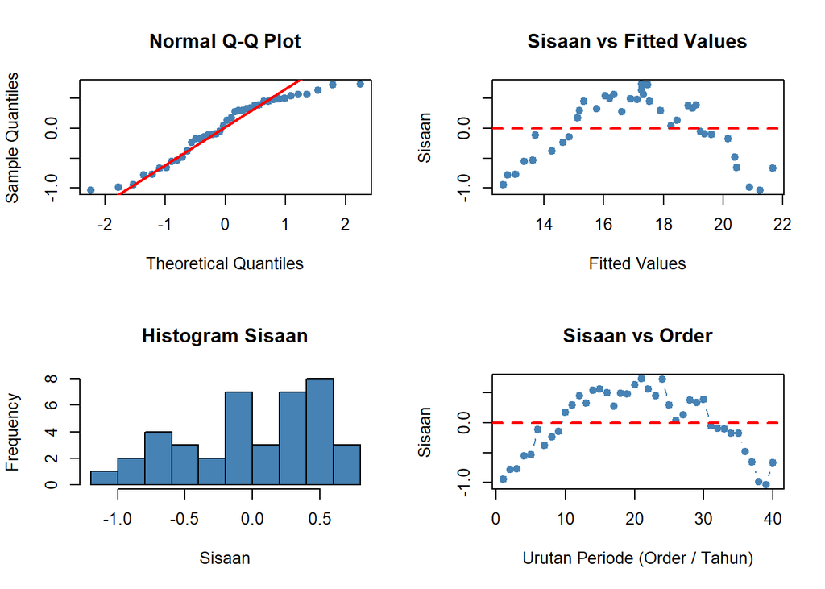

```r
sisaan <- residuals(model)
fitValue <- predict(model)

par(mfrow = c(2, 2))

# 1. Normal Q-Q Plot
qqnorm(sisaan, col = "steelblue", pch = 19)
qqline(sisaan, col = "red", lwd = 2)

# 2. Sisaan vs Fitted Values
plot(fitValue, sisaan, col = "steelblue", pch = 19,
     xlab = "Fitted Values", ylab = "Sisaan", main = "Sisaan vs Fitted Values")
abline(h = 0, col = "red", lwd = 2, lty = 2)

# 3. Histogram Sisaan
hist(sisaan, col = "steelblue", main = "Histogram Sisaan", xlab = "Sisaan")

# 4. Sisaan vs Order (Waktu)
plot(1:length(sisaan), sisaan, col = "steelblue", pch = 19, type = "b",
     xlab = "Urutan Periode (Order / Tahun)", ylab = "Sisaan", main = "Sisaan vs Order")
abline(h = 0, col = "red", lwd = 2, lty = 2)
```

```r
par(mfrow = c(1, 1))
```

Dua plot di samping kiri digunakan untuk melihat apakah sisaan menyebar normal. Normal Q-Q Plot dan Histogram di atas menunjukkan bahwa sisaan relatif berada di sekitar garis lurus. Selanjutnya, dua plot di samping kanan digunakan untuk melihat autokorelasi. Pada plot Sisaan vs Order, terlihat titik-titik sisaan membentuk pola sistematis/bergelombang dan tidak tersebar secara acak di sekitar sumbu nol yang mengindikasikan adanya autokorelasi pada sisaan.

# Uji Normalitas Sisaan

```r
# H0: Sisaan menyebar normal
# H1: Sisaan tidak menyebar normal
shapiro.test(sisaan)
```

```
##
##  Shapiro-Wilk normality test
##
## data:  sisaan
## W = 0.93205, p-value = 0.0188
```

```r
ks.test(sisaan, "pnorm", mean = mean(sisaan), sd = sd(sisaan))
```

```
##
##  Asymptotic one-sample Kolmogorov-Smirnov test
##
## data:  sisaan
## D = 0.15458, p-value = 0.2948
## alternative hypothesis: two-sided
```

Berdasarkan uji Kolmogorov-Smirnov didapatkan nilai p-value > $\alpha$ (5%), sehingga cukup bukti untuk menyatakan sisaan berdistribusi normal.

# Identifikasi Autokorelasi (Plot ACF, PACF, & Uji Durbin-Watson)

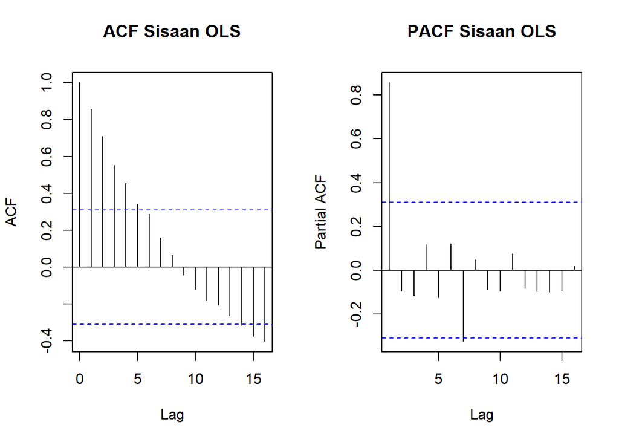

```r
# ACF dan PACF identifikasi autokorelasi
par(mfrow = c(1, 2))
acf(sisaan, main = "ACF Sisaan OLS")
pacf(sisaan, main = "PACF Sisaan OLS")
```

```r
# Nilai dL dan dU berdasarkan Tabel Durbin-Watson (alpha = 0.05, n = 40, k = 1)
dL <- 1.4421
dU <- 1.5444

cat("Nilai Batas Bawah (dL) :", dL, "\n")
```

```
## Nilai Batas Bawah (dL) : 1.4421
```

```r
cat("Nilai Batas Atas (dU)  :", dU, "\n")
```

```
## Nilai Batas Atas (dU)  : 1.5444
```

```r
# Uji Durbin-Watson
# H0: tidak ada autokorelasi
# H1: ada autokorelasi positif
dwtest(model)
```

```
##
##  Durbin-Watson test
##
## data:  model
## DW = 0.16204, p-value < 2.2e-16
## alternative hypothesis: true autocorrelation is greater than 0
```

Berdasarkan hasil DW Test, didapatkan nilai $DW = 0.16204$ dan p-value < $2.2 \times 10^{-16}$. Berdasarkan tabel Durbin-Watson diperoleh nilai $d_L = 1.4421$ dan $d_U = 1.5444$. Nilai $DW$ jauh lebih kecil dari $d_L$ ($0.16204 < 1.4421$) dan didukung dengan nilai p-value < 0.05, sehingga dapat disimpulkan tolak $H_0$, cukup bukti menyatakan adanya autokorelasi positif pada sisaan. Oleh karena itu, diperlukan penanganan autokorelasi menggunakan metode Cochrane-Orcutt dan Hildreth-Lu.

# Penanganan Autokorelasi

## Metode Cochrane-Orcutt

Penanganan metode Cochrane-Orcutt dapat dilakukan dengan bantuan packages orcutt pada aplikasi R maupun secara manual. Berikut ini ditampilkan cara menggunakan bantuan library packages orcutt.

```r
# Penanganan Autokorelasi Cochrane-Orcutt
modelCO <- cochrane.orcutt(model)
modelCO
```

```
## Cochrane-orcutt estimation for first order autocorrelation
##
## Call:
## lm(formula = sales ~ advertising, data = dtsales)
##
##  number of interaction: 39
##  rho 0.903123
##
## Durbin-Watson statistic
## (original):    0.16204 , p-value: 8.935e-20
## (transformed): 1.93925 , p-value: 3.78e-01
##
##  coefficients:
## (Intercept) advertising
##   10.252375    0.488489
```

```r
# Rho optimum
rho <- modelCO$rho
rho
```

```
## [1] 0.9031233
```

```r
# Transformasi Manual
n <- nrow(dtsales)
sales.trans <- dtsales$sales[-1] - dtsales$sales[-n] * rho
adv.trans <- dtsales$advertising[-1] - dtsales$advertising[-n] * rho

modelCOmanual <- lm(sales.trans ~ adv.trans)
summary(modelCOmanual)
```

```
##
## Call:
## lm(formula = sales.trans ~ adv.trans)
##
## Residuals:
##      Min       1Q   Median       3Q      Max
## -0.37730 -0.14957  0.01257  0.10464  0.45315
##
## Coefficients:
##             Estimate Std. Error t value Pr(>|t|)
## (Intercept)  0.99322    0.14141   7.023 2.64e-08 ***
## adv.trans    0.48849    0.07543   6.476 1.43e-07 ***
## ---
## Signif. codes:  0 '***' 0.001 '**' 0.01 '*' 0.05 '.' 0.1 ' ' 1
##
## Residual standard error: 0.1868 on 37 degrees of freedom
## Multiple R-squared:  0.5313, Adjusted R-squared:  0.5186
## F-statistic: 41.94 on 1 and 37 DF,  p-value: 1.426e-07
```

```r
# Mencari Penduga Koefisien Regresi setelah Transformasi ke Persamaan Awal
b0bintang <- modelCOmanual$coefficients[1]
b0 <- b0bintang / (1 - rho)
b1 <- modelCOmanual$coefficients[2]
b0
```

```
## (Intercept)
##    10.25237
```

```r
b1
```

```
## adv.trans
## 0.4884891
```

Hasil perhitungan koefisien regresi tersebut menghasilkan hasil yang sama persis dengan model yang dihasilkan menggunakan packages.

## Metode Hildreth-Lu

```r
# Fungsi Hildreth-Lu
hildreth.lu.func <- function(r, model){
  x <- model.matrix(model)[, -1]
  y <- model.response(model.frame(model))
  n <- length(y)
  t <- 2:n
  y <- y[t] - r * y[t - 1]
  x <- x[t] - r * x[t - 1]

  return(lm(y ~ x))
}

# Pencarian grid kasar (0.1 - 0.9)
r <- seq(0.1, 0.9, by = 0.1)
tab <- data.frame("rho" = r, "SSE" = sapply(r, function(i){deviance(hildreth.lu.func(i, model))}))
round(tab, 4)
```

```
##   rho    SSE
## 1 0.1 7.8457
## 2 0.2 6.3303
## 3 0.3 5.0154
## 4 0.4 3.9007
## 5 0.5 2.9856
## 6 0.6 2.2692
## 7 0.7 1.7494
## 8 0.8 1.4226
## 9 0.9 1.2914
```

```r
# Grid search teliti (ketelitian 0.001)
rOpt <- seq(0.1, 0.99, by = 0.001)
tabOpt <- data.frame("rho" = rOpt, "SSE" = sapply(rOpt, function(i){deviance(hildreth.lu.func(i, model))}))
head(tabOpt[order(tabOpt$SSE), ])
```

```
##       rho      SSE
## 804 0.903 1.291226
## 805 0.904 1.291239
## 803 0.902 1.291248
## 806 0.905 1.291289
## 802 0.901 1.291304
## 807 0.906 1.291375
```

```r
# Nilai rho optimum dengan SSE minimum
rho_opt <- tabOpt[tabOpt$SSE == min(tabOpt$SSE), "rho"]
rho_opt
```

```
## [1] 0.903
```

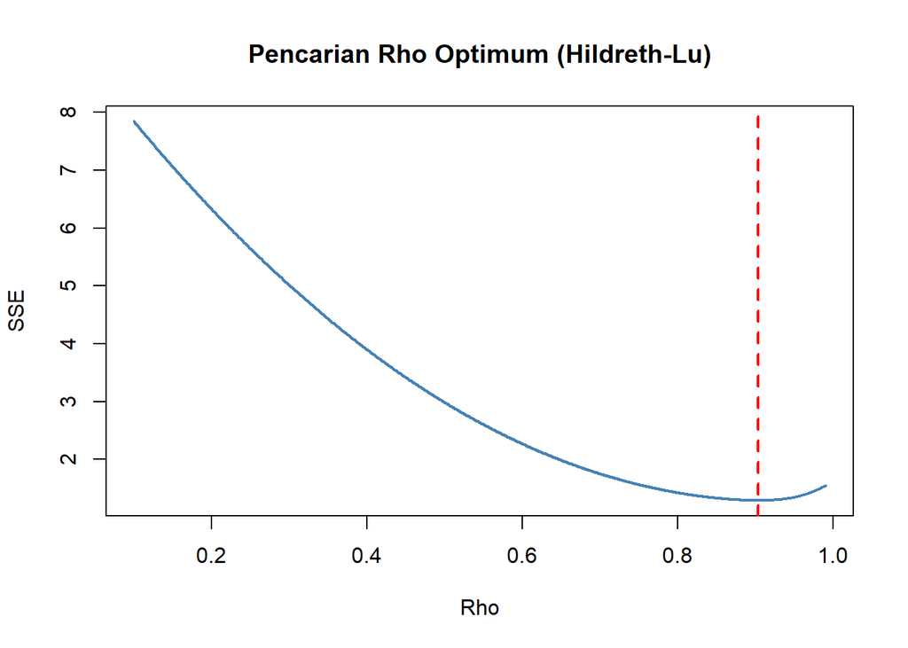

```r
# Plot SSE vs Rho
par(mfrow = c(1, 1))
plot(tabOpt$SSE ~ tabOpt$rho, type = "l", col = "steelblue", lwd = 2,
     xlab = "Rho", ylab = "SSE", main = "Pencarian Rho Optimum (Hildreth-Lu)")
abline(v = rho_opt, lty = 2, col = "red", lwd = 2)
```

Nilai $\rho$ optimum diperoleh pada $\rho = 0.903$.

```r
# Model Hildreth-Lu Terbaik
modelHL <- hildreth.lu.func(rho_opt, model)
summary(modelHL)
```

```
##
## Call:
## lm(formula = y ~ x)
##
## Residuals:
##      Min       1Q   Median       3Q      Max
## -0.37720 -0.14949  0.01266  0.10464  0.45301
##
## Coefficients:
##             Estimate Std. Error t value Pr(>|t|)
## (Intercept)  0.99401    0.14144   7.028 2.60e-08 ***
## x            0.48869    0.07536   6.485 1.39e-07 ***
## ---
## Signif. codes:  0 '***' 0.001 '**' 0.01 '*' 0.05 '.' 0.1 ' ' 1
##
## Residual standard error: 0.1868 on 37 degrees of freedom
## Multiple R-squared:  0.532,  Adjusted R-squared:  0.5193
## F-statistic: 42.05 on 1 and 37 DF,  p-value: 1.39e-07
```

```r
# Transformasi Balik Parameter Asli
b0_hl <- coef(modelHL)[1] / (1 - rho_opt)
b1_hl <- coef(modelHL)[2]
cat("Persamaan Model Hildreth-Lu:\n")
```

```
## Persamaan Model Hildreth-Lu:
```

```r
cat("y = ", b0_hl, " + (", b1_hl, ") x\n", sep = "")
```

```
## y = 10.24749 + (0.4886925) x
```

```r
# Uji Durbin-Watson Model Hildreth-Lu
dwtest(modelHL)
```

```
##
##  Durbin-Watson test
##
## data:  modelHL
## DW = 1.9393, p-value = 0.378
## alternative hypothesis: true autocorrelation is greater than 0
```

Hasil uji Durbin-Watson pada model Hildreth-Lu menghasilkan nilai $DW = 1.9393$ dan p-value = $0.378> 0.05$, membuktikan bahwa sisaan model telah terbebas dari masalah autokorelasi.

# Perbandingan Model & Evaluasi

```r
# Perhitungan SSE dan MSE Ketiga Model
sseModelawal <- deviance(model)
sseModelCO   <- deviance(modelCOmanual)
sseModelHL   <- deviance(modelHL)

mseModelawal <- sseModelawal / nrow(dtsales)
mseModelCO   <- sseModelCO / (nrow(dtsales) - 1)
mseModelHL   <- sseModelHL / (nrow(dtsales) - 1)

akurasi <- matrix(c(sseModelawal, sseModelCO, sseModelHL,
                    mseModelawal, mseModelCO, mseModelHL),
                  nrow = 2, ncol = 3, byrow = TRUE)
colnames(akurasi) <- c("Model Awal (OLS)", "Model Cochrane-Orcutt", "Model Hildreth-Lu")
row.names(akurasi) <- c("SSE", "MSE")
akurasi
```

```
##     Model Awal (OLS) Model Cochrane-Orcutt Model Hildreth-Lu
## SSE       10.5545322            1.29122545        1.29122572
## MSE        0.2638633            0.03310834        0.03310835
```

Berdasarkan tabel di atas, penanganan autokorelasi menggunakan metode Cochrane-Orcutt maupun Hildreth-Lu menghasilkan nilai SSE yang identik yaitu sebesar 1.29123 (jauh lebih kecil dibandingkan model OLS awal sebesar 10.55453). Nilai MSE juga mengalami penurunan dari 0.26386 menjadi 0.03311.

# Simpulan